# BayesGrid

GB

24.03.2022

## Exercise: Programm a simple grid approximation to obtain a posterior distribution

Please download a copy of this document and fill in the relevant sections below.

### Data

Use this data about arrivals times relative to the start of a lecture.

```r
my_data =
  read.table(
    "arrival.csv",
    header = T,
    sep = ",")
head(my_data)
```

```
##   age time
## 1  31   -1
## 2  19    0
## 3  24   -1
## 4  23   -1
## 5  24   -5
## 6  21   -1
```

Here is the plot of the data

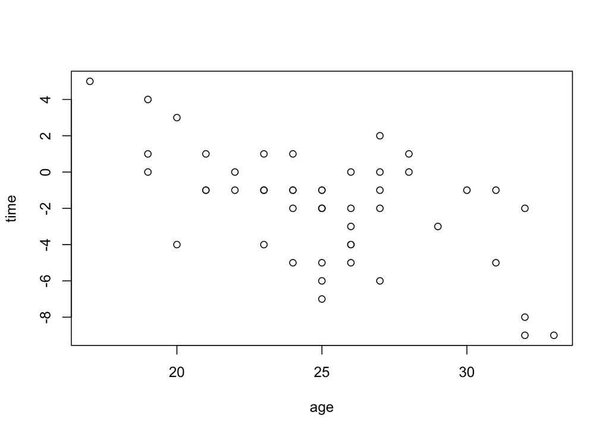

```r
with(my_data,
     plot(age, time))
```

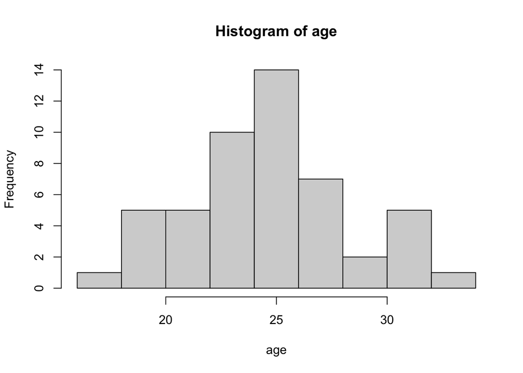

```r
age = my_data$age
hist(age)
```

### The Model

For now we are only interested in estimating the mean age (`age`) using the following model. The table shows the (incomplete) model expressed with equations, quap code fragments, and how one would calculate quantities directltly in R.

| What | Notation | quap code | r-code |
| --- | --- | --- | --- |
| Likelihood | $a_i \sim Normal(\mu,\sigma)$ | `age ~ dnorm(mu, sigma)` | `L[i] = dnorm(age[i], mu, sigma)` |
| Prior | $\mu \sim Normal(25,3)$ | `mu ~ dnorm(25, 3)` | `p_mu = dnorm(mu, 25 , 3)` |
| Prior | $\sigma \sim Exponential(1)$ | `sigma ~ dexp(1)` | `p_sigma = dexp(sigma,1)` |

Your first task is to complete the model to do this. Please add the missing information in the table above. You need to add the parameter values to the priors. You also have to choose a distribution and parameter(s) for the standard deviation $\sigma$.

### The posterior disribution

The posterior distribution is calculated as follows:

$$\overset{Posterior}{P(\mu,\sigma|w)} =
\frac{\prod_i \overset{Likelihood}{Normal(a_i|\mu,\sigma)} \cdot
\overset{Prior}{Normal(\mu|25,3)Exponential(\sigma|1)}}
{\overset{Evidence}{\int\int \prod_i Normal(a_i|\mu,\sigma) \cdot Normal(\mu|25,3)Exponential(\sigma|1)d\mu d\sigma}}$$

Please add the missing information wherever are three dots $...$ or it reads $YourDist$.

### Calculate the likelihood for a data point

Lets assume that these parameter values

- `mu = 22`
- `sd = 3`

Please calculate the likelihood for the first data point in the vector `temp` in the next code block. If you are uncertain about how to proceed, check the table above

```r
# Likelihood for the first data point
L = dnorm(age[1],22,3)
L
```

```
## [1] 0.001477283
```

Now calculate the probability of the data point given the parameter values for each recorded age You do not need a loop to do this!

```r
# Likelihoods for all individual data points
L = dnorm(age,22,3)
head(L)
```

```
## [1] 0.001477283 0.080656908 0.106482669 0.125794409 0.106482669 0.125794409
```

And now calculate the joint probability of all recorded ages. (Read the help for the `prod` function, i.e. type `?prod`in the console)

```r
# Joint likelihoods for all individual data points
prod(L)
```

```
## [1] 2.930732e-72
```

Now calculate the prior probability of the the parameters `mu = 22` and `sd = 3`. You should use the prior distributions you specified above for this,

```r
P_par = c(NA,NA)
# Prior probability for mu = 22
P_par[1] = dnorm(22,25,3)
# Prior probability for sd = 3
P_par[2] = dexp(3,1)
```

```r
# Point prior probability for mu = 22 and sd = 3
prod(P_par)
```

```
## [1] 0.004015671
```

Now you should be able to calculate the numerator of the equation above for `mu = 22` and `sd = 3`.

```r
# Joint probability of data and parameters for  mu = 22 and sd = 3
# given the prior distributions for mu and sd
prod(L)*prod(P_par)
```

```
## [1] 1.176886e-74
```

Now that you have calculated the joint probability of data and parameters given the prior distributions for mu and sd for one set of parameters, we can do this for a combination of parameters. Continue either with **Grid approximation, version 1** or **Grid approximation, version 2**.

## Grid approximation, version 1

First set up the grid. You can use the the code example below. Feel free to change the range of the parameters you explore by changing the first and second number in the `seq` commands

```r
# Here we are making our grid
params =
  expand.grid(
    mu = seq(20,30,.1),
    sd = seq(2.5,4.5, .025)
  )
params = data.frame(params)
head(params)
```

```
##     mu  sd
## 1 20.0 2.5
## 2 20.1 2.5
## 3 20.2 2.5
## 4 20.3 2.5
## 5 20.4 2.5
## 6 20.5 2.5
```

```r
tail(params)
```

```
##        mu  sd
## 8176 29.5 4.5
## 8177 29.6 4.5
## 8178 29.7 4.5
## 8179 29.8 4.5
## 8180 29.9 4.5
## 8181 30.0 4.5
```

Now you can calculate the unnormalized posterior for all parameter combinations. It is easiest to use a for loops for this.

Store the result for each parameter combination in the the variable `UP`.

```r
# Here comes your code in which you calculate the 'likelihood * prior expression'
# (see the formula or your code above) for each combination of parameter values.

for (k in 1:nrow(params)) {
  mu = params$mu[k]
  sd = params$sd[k]
  params$UP[k] = prod(dnorm(age,mu,sd)) * dnorm(mu,25,3) * dexp(sd,1)
}
```

### Calculate the evidence

Use the data.frame `params` that you just created, specifically one column in it, to calculate the *evidence*. If you are uncertain, check the equation above

```r
# Calculate evidence
evidence = sum(params$UP)
```

### Normalize to get a proper posterior distribution.

Now you can use the evidence to add a one more column to the `params` data frame, let’s call it `PP`, which has the posterior probability for each parameter combination.

```r
# Calculate posterior probabilities
params$P = params$UP/evidence
```

### Plot the posterior

Make a plot of the posterior

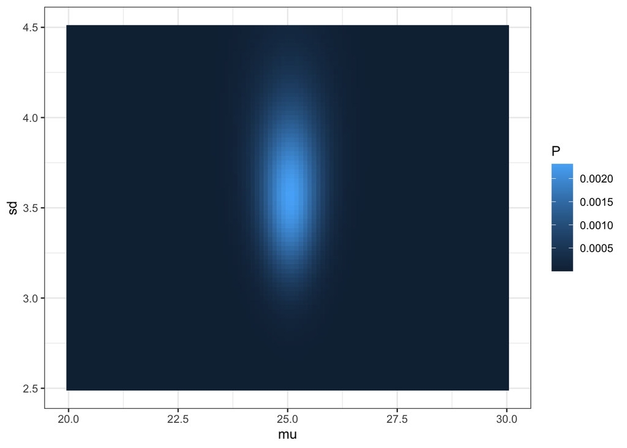

```r
# Plot posterior probabilities
# The easiest is to use ggplot here, following this pattern
# ggplot(params, aes(x = mu, y = sd, z = PP)) + geom_contour_filled()
# which assumes that you have called you column for posterior
# probabilities "PP"
library(ggplot2)
ggplot(params, aes(x = mu, y = sd, fill = P)) +
  geom_raster() +
  theme_bw()
```

We can also draw posterior samples and plot those:

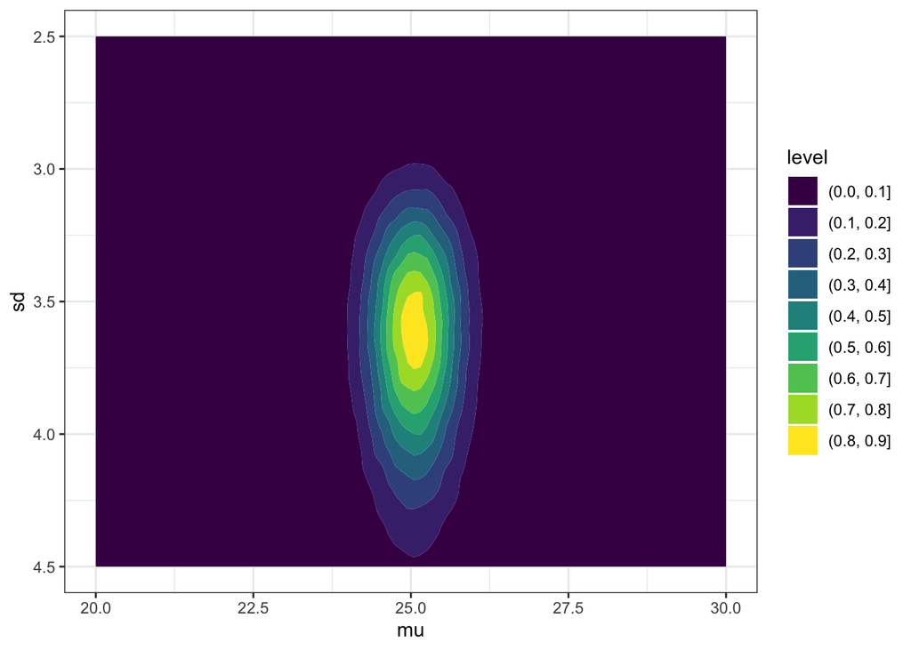

```r
post =
  data.frame(
    sd = sample(params$sd,25e4,prob = params$UP, replace = T),
    mu = sample(params$mu,25e4,prob = params$UP, replace = T)
  )

ggplot(post, aes(x = mu, y = sd)) +
  geom_density_2d_filled() +
  ylim(4.5,2.5) +
  xlim(20,30) +
  theme_bw()
```

## Grid approximation, version 2

Here is a template to generate a grid of parameters. Your main task here is to add the code to calculate the un-normalized posterior. You have to set `eval = TRUE` at the beginning of the code block so that the code is run when you knit the document.

```r
N_grid_points <-100

# Make a set of grid values for the two parameters
my_mu<-seq(from=20, to=30, length.out=N_grid_points)
my_sigma<-seq(from=2.5, to=4.5, length.out=N_grid_points)

# Make an empty placeholder for the posterior
posterior_unstandardized<-matrix(NA,ncol=N_grid_points, nrow=N_grid_points)

# Calculate the posterior in each grid point
for (i in 1:N_grid_points)
  for (j in 1:N_grid_points)
  {
    posterior_unstandardized[i,j] <-
      prod(dnorm(age,mean=my_mu[i], sd=my_sigma[j])) * dnorm(my_mu[i],25,2)*dexp(my_sigma[j],0.5)
  }
```

Next, you need to calculate the evidence and standardize the posterior

```r
posterior=posterior_unstandardized/sum(posterior_unstandardized)
```

And here is some code to plot the results

Plot the results.

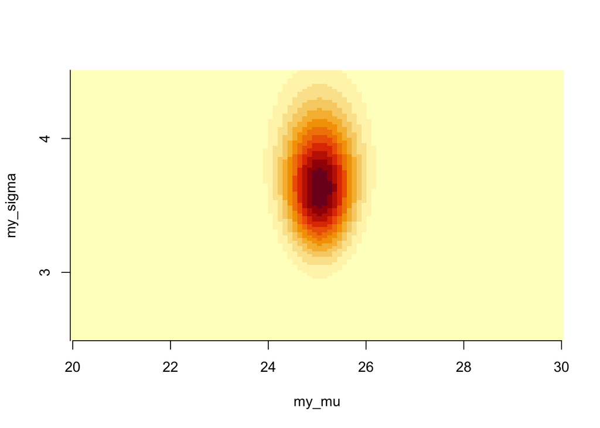

```r
# Plot (2D) image of the posterior
image(my_mu,my_sigma,posterior,  axes=FALSE);
axis(1, at = seq(20, 30, by = 2))
axis(2, at = seq(0, 5, by = 1))
```

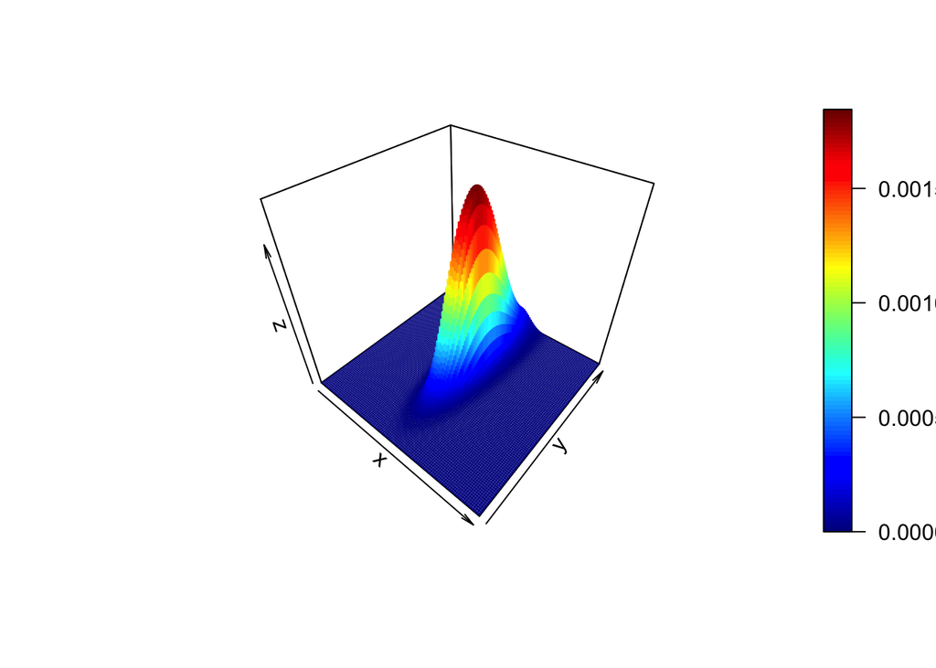

```r
# Plot (3D) histogram
library(plot3D)
hist3D(z=posterior, border=NA)
```

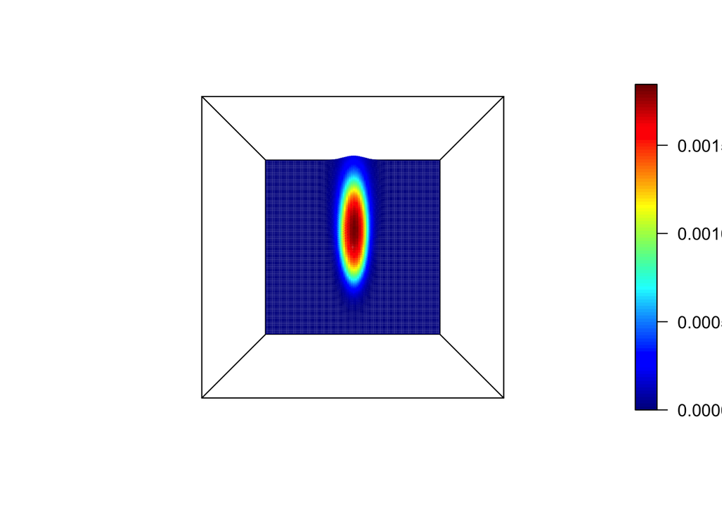

```r
hist3D(z=posterior, border=NA, theta = 0, phi = 90)
```

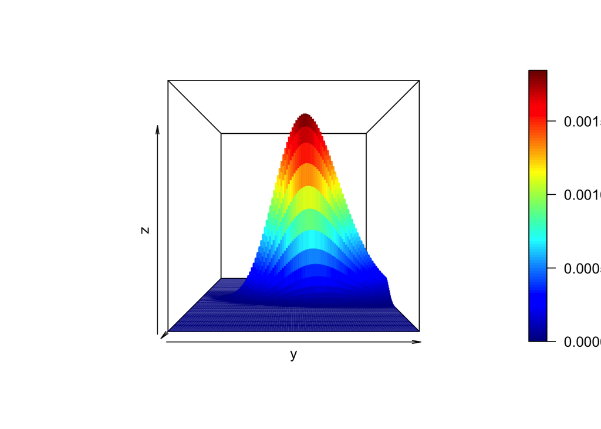

```r
hist3D(z=posterior, border=NA, theta = 90, phi = 0)
```